# Prediction Assignment Writeup

Heidi Peterson

3/12/2020

One thing that people regularly do is quantify how much of a particular activity they do, but they rarely quantify how well they do it. In this project, your goal will be to use data from accelerometers on the belt, forearm, arm, and dumbell of 6 participants.

The goal of your project is to predict the manner in which they did the exercise. This is the “classe” variable in the training set. You may use any of the other variables to predict with. You should create a report describing how you built your model, how you used cross validation, what you think the expected out of sample error is, and why you made the choices you did. You will also use your prediction model to predict 20 different test cases.

```r
library(rpart)
```

```r
trainingset <- read.csv("https://d396qusza40orc.cloudfront.net/predmachlearn/pml-training.csv", na.strings=c("NA","#DIV/0!", ""))
testingset <- read.csv("https://d396qusza40orc.cloudfront.net/predmachlearn/pml-testing.csv", na.strings=c("NA","#DIV/0!", ""))
```

```r
NATraining <- sapply(trainingset, function(x) {sum(is.na(x))})
trainingset <- trainingset[,which(NATraining == 0)]

NATesting <- sapply(testingset, function(x) {sum(is.na(x))})
testingset <- testingset[, which(NATesting == 0)]

trainingset <- trainingset[,-c(1:6)]
testingset <- testingset[, -c(1:6)]
trainingset<-data.frame(trainingset)
testingset<-data.frame(testingset)
```

```r
library(caret)
set.seed(123)
inTrain <- createDataPartition(trainingset$classe, p = 0.7, list = FALSE)
training <- trainingset[inTrain,]
testing <- trainingset[-inTrain,]
```

## Decision Tree Model

Six young health participants were asked to perform one set of 10 repetitions of the Unilateral Dumbbell Biceps Curl in five different fashions: exactly according to the specification (Class A), throwing the elbows to the front (Class B), lifting the dumbbell only halfway (Class C), lowering the dumbbell only halfway (Class D) and throwing the hips to the front (Class E).

Class A corresponds to the specified execution of the exercise, while the other 4 classes correspond to common mistakes.

[figure not shown]

```r
class_prediction <- predict( model, testing, type = "class")

confusionMatrix(class_prediction, testing$classe)
```

```
## Confusion Matrix and Statistics
##
##           Reference
## Prediction    A    B    C    D    E
##          A 1459   86    0   13    2
##          B  104  855   61   75   51
##          C    0   57  856   37    3
##          D   92   81   99  759   86
##          E   19   60   10   80  940
##
## Overall Statistics
##
##                Accuracy : 0.8274
##                  95% CI : (0.8175, 0.8369)
##     No Information Rate : 0.2845
##     P-Value [Acc > NIR] : < 2.2e-16
##
##                   Kappa : 0.7823
##
##  Mcnemar's Test P-Value : NA
##
## Statistics by Class:
##
##                      Class: A Class: B Class: C Class: D Class: E
## Sensitivity            0.8716   0.7507   0.8343   0.7873   0.8688
## Specificity            0.9760   0.9387   0.9800   0.9273   0.9648
## Pos Pred Value         0.9353   0.7461   0.8982   0.6795   0.8476
## Neg Pred Value         0.9503   0.9401   0.9655   0.9570   0.9703
## Prevalence             0.2845   0.1935   0.1743   0.1638   0.1839
## Detection Rate         0.2479   0.1453   0.1455   0.1290   0.1597
## Detection Prevalence   0.2651   0.1947   0.1619   0.1898   0.1884
## Balanced Accuracy      0.9238   0.8447   0.9072   0.8573   0.9168
```

## RANDOM FOREST MODEL

Grab OOB error matrix

```r
library(randomForest)
model2 <- randomForest(classe ~. , data=training, method="class")

# Grab OOB error matrix & take a look
err <- model2$err.rate
head(err)
```

```
##             OOB          A          B          C          D          E
## [1,] 0.08920283 0.04612006 0.11620795 0.09038902 0.12254902 0.09368192
## [2,] 0.08635918 0.04559404 0.11291329 0.09600561 0.11512415 0.08531746
## [3,] 0.08443090 0.04833625 0.10836694 0.09794101 0.11561743 0.07370095
## [4,] 0.07474430 0.04054472 0.09389039 0.08622398 0.10980182 0.06485455
## [5,] 0.06636808 0.03195164 0.08988294 0.07613265 0.09356436 0.06080781
## [6,] 0.05746768 0.03106956 0.07234213 0.06723442 0.07874763 0.05414552
```

```r
# Look at final OOB error rate (last row in err matrix)
oob_err <- err[nrow(err), "OOB"]
print(oob_err)
```

```
##         OOB
## 0.002693456
```

plot Random Forest Model

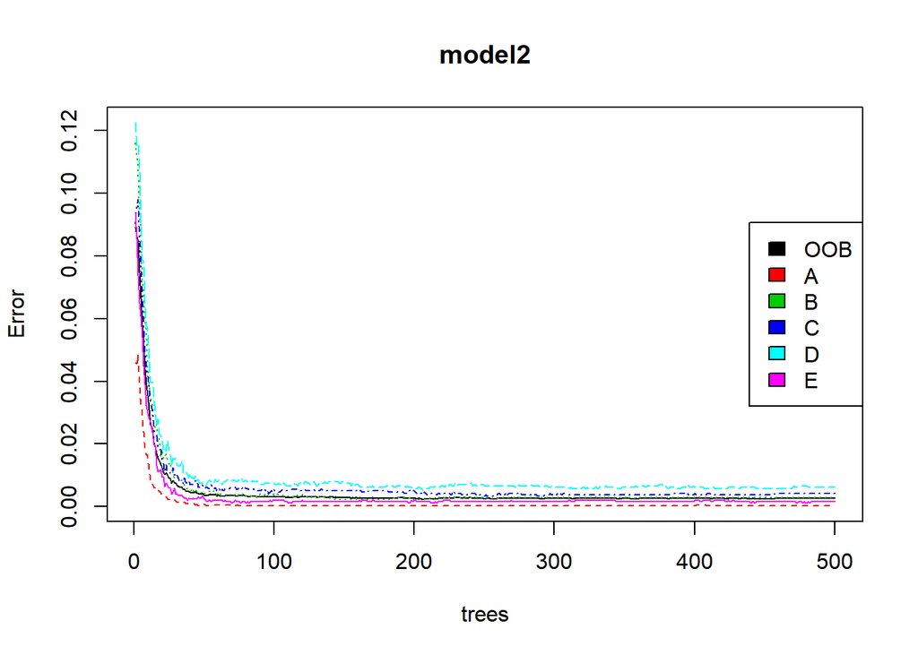

```r
plot(model2)
# Add a legend since it doesn't have one by default
legend(x = "right",
       legend = colnames(err),
       fill = 1:ncol(err))
```

prediction and confusion matrix for random forest model

```r
prediction2 <- predict(model2, testing, type = "class")
cm <-confusionMatrix(prediction2, testing$classe)
print(cm)
```

```
## Confusion Matrix and Statistics
##
##           Reference
## Prediction    A    B    C    D    E
##          A 1674    0    0    0    0
##          B    0 1136    1    0    0
##          C    0    3 1025    2    0
##          D    0    0    0  962    4
##          E    0    0    0    0 1078
##
## Overall Statistics
##
##                Accuracy : 0.9983
##                  95% CI : (0.9969, 0.9992)
##     No Information Rate : 0.2845
##     P-Value [Acc > NIR] : < 2.2e-16
##
##                   Kappa : 0.9979
##
##  Mcnemar's Test P-Value : NA
##
## Statistics by Class:
##
##                      Class: A Class: B Class: C Class: D Class: E
## Sensitivity            1.0000   0.9974   0.9990   0.9979   0.9963
## Specificity            1.0000   0.9998   0.9990   0.9992   1.0000
## Pos Pred Value         1.0000   0.9991   0.9951   0.9959   1.0000
## Neg Pred Value         1.0000   0.9994   0.9998   0.9996   0.9992
## Prevalence             0.2845   0.1935   0.1743   0.1638   0.1839
## Detection Rate         0.2845   0.1930   0.1742   0.1635   0.1832
## Detection Prevalence   0.2845   0.1932   0.1750   0.1641   0.1832
## Balanced Accuracy      1.0000   0.9986   0.9990   0.9986   0.9982
```

```r
# Compare test set accuracy to OOB accuracy
paste0("Test Accuracy: ", cm$overall[1])
```

```
## [1] "Test Accuracy: 0.998300764655905"
```

```r
paste0("OOB Accuracy: ", 1 - oob_err)
```

```
## [1] "OOB Accuracy: 0.997306544369222"
```

Let us take a look to which model is better it says the random forest is 99% accurate compaired to decission tree which is 83% accurate so we will use model 2 random forest on our test set.

```r
for (i in 1:20) {
  p <- predict(model2, testingset[i,])
  print(p)
}
```

```
## 1
## B
## Levels: A B C D E
## 2
## A
## Levels: A B C D E
## 3
## B
## Levels: A B C D E
## 4
## A
## Levels: A B C D E
## 5
## A
## Levels: A B C D E
## 6
## E
## Levels: A B C D E
## 7
## D
## Levels: A B C D E
## 8
## B
## Levels: A B C D E
## 9
## A
## Levels: A B C D E
## 10
##  A
## Levels: A B C D E
## 11
##  B
## Levels: A B C D E
## 12
##  C
## Levels: A B C D E
## 13
##  B
## Levels: A B C D E
## 14
##  A
## Levels: A B C D E
## 15
##  E
## Levels: A B C D E
## 16
##  E
## Levels: A B C D E
## 17
##  A
## Levels: A B C D E
## 18
##  B
## Levels: A B C D E
## 19
##  B
## Levels: A B C D E
## 20
##  B
## Levels: A B C D E
```